# Heart Attack - Analysis and Prediction

Ramath Kunasan

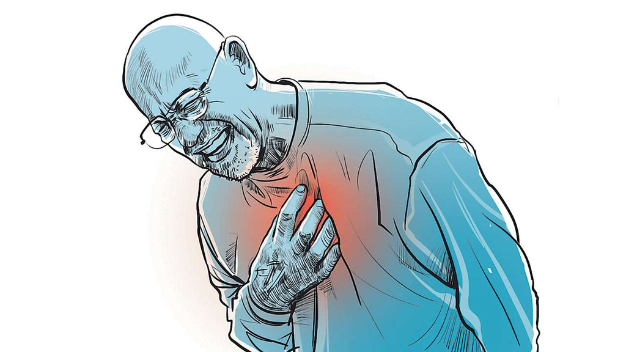

# 1.Introduction

## Data Dictionary

- **age** - Age of the patient
- **cp** - Chest pain type ~ 0 = Typical Angina, 1 = Atypical Angina, 2 = Non-anginal Pain, 3 = Asymptomatic
- **trtbps** - Resting blood pressure (in mm Hg)
- **chol** - Cholestoral in mg/dl fetched via BMI sensor
- **fbs** - (fasting blood sugar > 120 mg/dl) ~ 1 = True, 0 = False
- **restecg** - Resting electrocardiographic results ~ 0 = Normal, 1 = ST-T wave normality, 2 = Left ventricular hypertrophy
- **thalachh** - Maximum heart rate achieved
- **exng** - Exercise induced angina ~ 1 = Yes, 0 = No
- **oldpeak** - Previous peak
- **slp** - Slope
- **caa** - Number of major vessels
- **thall** - Thalium Stress Test result ~ (0,3)
- **output** - Target variable

## Loading data and library

```r
library(tidyverse)
library(GGally)
library(ggplot2)
library(highcharter)
library(plotly)
library(viridisLite)
library(cowplot)
library(treemap)
library(tm)
library(wordcloud)
library(RColorBrewer)
library(maps)
library(countrycode)
library(purrr)
library(htmltools)
df <- read.csv('heart.csv') ## https://www.kaggle.com/rashikrahmanpritom/heart-attack-analysis-prediction-dataset/download
primaryColor <- '#fc053f'
```

## Preview data

### Types of Data

```r
df %>% glimpse()
```

```
## Rows: 303
## Columns: 14
## $ age      <int> 63, 37, 41, 56, 57, 57, 56, 44, 52, 57, 54, 48, 49, 64, 58...
## $ sex      <int> 1, 1, 0, 1, 0, 1, 0, 1, 1, 1, 1, 0, 1, 1, 0, 0, 0, 0, 1, 0...
## $ cp       <int> 3, 2, 1, 1, 0, 0, 1, 1, 2, 2, 0, 2, 1, 3, 3, 2, 2, 3, 0, 3...
## $ trtbps   <int> 145, 130, 130, 120, 120, 140, 140, 120, 172, 150, 140, 130...
## $ chol     <int> 233, 250, 204, 236, 354, 192, 294, 263, 199, 168, 239, 275...
## $ fbs      <int> 1, 0, 0, 0, 0, 0, 0, 0, 1, 0, 0, 0, 0, 0, 1, 0, 0, 0, 0, 0...
## $ restecg  <int> 0, 1, 0, 1, 1, 1, 0, 1, 1, 1, 1, 1, 1, 0, 0, 1, 1, 1, 1, 1...
## $ thalachh <int> 150, 187, 172, 178, 163, 148, 153, 173, 162, 174, 160, 139...
## $ exng     <int> 0, 0, 0, 0, 1, 0, 0, 0, 0, 0, 0, 0, 0, 1, 0, 0, 0, 0, 0, 0...
## $ oldpeak  <dbl> 2.3, 3.5, 1.4, 0.8, 0.6, 0.4, 1.3, 0.0, 0.5, 1.6, 1.2, 0.2...
## $ slp      <int> 0, 0, 2, 2, 2, 1, 1, 2, 2, 2, 2, 2, 2, 1, 2, 1, 2, 0, 2, 2...
## $ caa      <int> 0, 0, 0, 0, 0, 0, 0, 0, 0, 0, 0, 0, 0, 0, 0, 0, 0, 0, 0, 2...
## $ thall    <int> 1, 2, 2, 2, 2, 1, 2, 3, 3, 2, 2, 2, 2, 2, 2, 2, 2, 2, 2, 2...
## $ output   <int> 1, 1, 1, 1, 1, 1, 1, 1, 1, 1, 1, 1, 1, 1, 1, 1, 1, 1, 1, 1...
```

### Describe stats

```r
df %>%
   select(age, chol, thalachh, trtbps, oldpeak)%>%
    summary()
```

```
##       age             chol          thalachh         trtbps         oldpeak
##  Min.   :29.00   Min.   :126.0   Min.   : 71.0   Min.   : 94.0   Min.   :0.00
##  1st Qu.:47.50   1st Qu.:211.0   1st Qu.:133.5   1st Qu.:120.0   1st Qu.:0.00
##  Median :55.00   Median :240.0   Median :153.0   Median :130.0   Median :0.80
##  Mean   :54.37   Mean   :246.3   Mean   :149.6   Mean   :131.6   Mean   :1.04
##  3rd Qu.:61.00   3rd Qu.:274.5   3rd Qu.:166.0   3rd Qu.:140.0   3rd Qu.:1.60
##  Max.   :77.00   Max.   :564.0   Max.   :202.0   Max.   :200.0   Max.   :6.20
```

```r
load_cat <- function(frame) {

  sorted_df <- frame %>%
              drop_na() %>%
              summarise(Count = n()) %>%
              arrange(desc(Count)) %>%
              mutate(percentage = paste0(round(Count / sum(Count) * 100, 1), "%"))

    return(sorted_df)
}
```

## Clean Daat

```r
get_duplicates <- function(df){
    total_rows = dim(df)[1]
    unique_rows = dim(df %>% group_by_all %>% count)[1]
    n_duplicates = (total_rows - unique_rows)
    cat('n duplicates -> ', n_duplicates)
}

get_duplicates(df)
```

```
## n duplicates ->  1
```

```r
df = unique(df)

cat('removing duplicate rows')
```

```
## removing duplicate rows
```

```r
get_duplicates(df)
```

```
## n duplicates ->  0
```

# 2.Analysis and Visualization

## Coding create function plot histogram

```r
print_column_chart = function(name, title){
   keeps <- c(name, 'output')
   frame = df[ , (names(df) %in% keeps)]

  normal_chart <- hchart(frame[, (names(frame) %in% name)], type = "column",
                         color = "#ff78a7") %>%
    hc_title(text= title) %>%
    #hc_add_theme(hc_theme_google()) %>%
    hc_xAxis(title = name) %>%
    hc_chart(options2d=list(enabled=TRUE, alpha=2, beta=-10,
                            depth=100, viewDistance=25)) %>%
    hc_plotOptions(column=list(depth= 100))

   htmltools::tagList(normal_chart)

}
```

## Histogram data

### Persons Age

```r
summary(df$age)
```

```
##    Min. 1st Qu.  Median    Mean 3rd Qu.    Max.
##   29.00   48.00   55.50   54.42   61.00   77.00
```

```r
print_column_chart('age', 'Persons Age')
```

[interactive chart not shown]

### Cholestoral

```r
print_column_chart('chol', 'Cholestoral')
```

[interactive chart not shown]

### Maximum Heart Rate Achieved

```r
print_column_chart('thalachh', 'Maximum Heart Rate Achieved')
```

[interactive chart not shown]

### Resting Blood Pressure

```r
summary(df$trtbps)
```

```
##    Min. 1st Qu.  Median    Mean 3rd Qu.    Max.
##    94.0   120.0   130.0   131.6   140.0   200.0
```

```r
print_column_chart('trtbps', 'Resting Blood Pressure')
```

[interactive chart not shown]

### oldpeak (Previous peak)

```r
print_column_chart('oldpeak', 'Previous peak')
```

[interactive chart not shown]

## Dense plots on Quantitative data

```r
print_dense_chart = function(name, title){

    keeps <- c(name, 'output')
    frame = df[ , (names(df) %in% keeps)]

    normal <- frame %>% filter(output == 0)
    heart_attack <- frame %>% filter(output == 1)

   dense_plot <- hchart(
      density(normal[, (names(normal) %in% name)]), type = "area",
      color = "#0463bd",
       name = "Normal"
    ) %>%
      hc_add_series(
      density(heart_attack[, (names(heart_attack) %in% name)]), type = "area",
      color = "#fc053f",
      name = "Heart Attack"
   ) %>%
    hc_title(text= title) %>%
    hc_xAxis(title = name) %>%
    hc_add_theme(hc_theme_google())

  htmltools::tagList(dense_plot)

}
```

### Persons Age

```r
print_dense_chart('age', 'Persons Age')
```

[interactive chart not shown]

### Cholestoral

```r
print_dense_chart('chol', 'Cholestoral')
```

[interactive chart not shown]

### Maximum Heart Rate Achieved

```r
print_dense_chart('thalachh', 'Maximum Heart Rate Achieved')
```

[interactive chart not shown]

### Resting Blood Pressure

```r
print_dense_chart('trtbps', 'Resting Blood Pressure')
```

[interactive chart not shown]

### oldpeak (Previous peak)

```r
print_dense_chart('oldpeak', 'ST depression induced by exercise relative to rest')
```

[interactive chart not shown]

## Box plots on Quantitative data

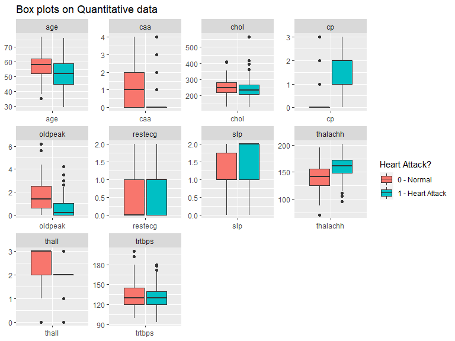

```r
options(repr.plot.width = 12, repr.plot.height = 10)

heart_df %>%
    pivot_longer(cols = c(age, cp:chol, restecg, thalachh, oldpeak:thall), names_to = "attributes",
                 values_to = "value") %>%
    ggplot(aes(attributes, value, fill = output)) +
    geom_boxplot() +
    facet_wrap(vars(attributes), scales = "free") +
    labs(title = "Box plots on Quantitative data",
         fill = "Heart Attack?",
         x = NULL,
         y = NULL)
```

## How one category effect other categories

```r
make_string_heart <- function(bool_var){
  char_list = c(1, length(bool_var))
  for (i in 1:length(bool_var)) {
    var = bool_var[i]
    new_char = 'unknown'

    if(var == 0){
        new_char = 'Normal'
     }

    if(var == 1){
        new_char = '1 - HA'
    }

     char_list[i] =  new_char
   }

    return(char_list)
 }


frame <- df %>%
            select(age, chol, thalachh, trtbps, oldpeak, output, caa, cp, sex, thall, exng, fbs, restecg, slp) #%>%
            #filter((thall > 0) & (caa < 3) & (restecg < 2) & (slp > 0) & (cp < 3))


frame$output <- make_string_heart(frame$output)
frame$output <- as.factor(frame$output)

frame$caa <- as.factor(frame$caa)
frame$cp <- as.factor(frame$cp)
frame$sex <- make_string_sex(frame$sex)
frame$thall <- as.factor(frame$thall)
frame$exng <- as.factor(frame$exng)
frame$fbs <- as.factor(frame$fbs)
frame$restecg <- as.factor(frame$restecg)
frame$slp <- as.factor(frame$slp)


DrawPairs <- function(frame, y_axis, type){

    if(type == 'cat'){
      pairs <- ggpairs(frame, mapping = ggplot2::aes(color=output))
    }

    else if(type == 'cat2'){
      pairs <- ggpairs(frame,columns = 1:5, mapping = ggplot2::aes(color=output),
                       #diag = list(continuous = "blankDiag")
                )
    }
    else{
      pairs <- ggpairs(frame,columns = 1:5, mapping = aes(color=output), lower=list(continuous=wrap("smooth"), binwidth=0.5),
                      #diag = list(continuous = "blankDiag")
                      )
    }

     for(i in 1:pairs$nrow) {
        for(j in 1:pairs$ncol){
           pairs[i,j] <- pairs[i,j] +
           scale_fill_manual(values=c("#fc053f", '#0463bd')) +
           scale_color_manual(values=c("#fc053f", '#0463bd'))
       }
    }

    if(type == 'int'){
        nrow = 1
        plots <- lapply(1:pairs$ncol, function(j) getPlot(pairs, i = j, j = 1))
    }
    else{
        nrow = 1
       plots <- lapply(1:pairs$ncol, function(j) getPlot(pairs, i = 1, j = j))
    }

    ggmatrix(
       plots,
       nrow = nrow,
       ncol = pairs$ncol,
       yAxisLabels = y_axis,
       xAxisLabels = pairs$xAxisLabels) + theme_minimal()

}
```

### Gender

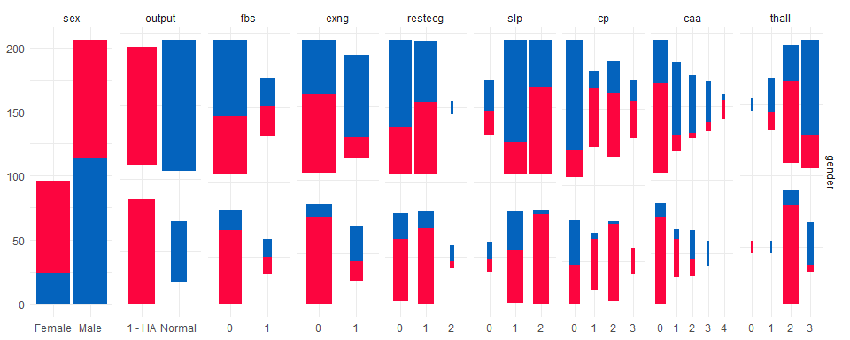

```r
new_frame <- frame %>%
              select(sex, output, fbs, exng, restecg, slp, cp, caa, thall)

y_axis = c('gender')

DrawPairs(new_frame, y_axis, type='cat')
```

- **Women** are more likely to have **heart problem** than **men** (based on ratio)

### fbs

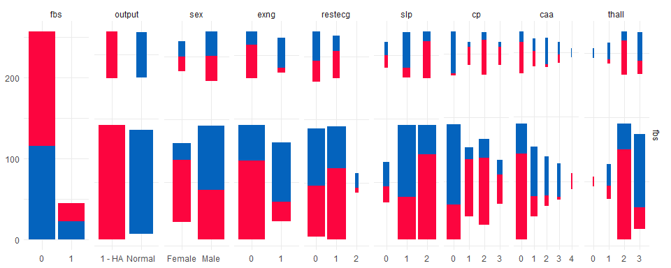

```r
new_frame <- frame %>%
              select(fbs, output, sex, exng, restecg, slp, cp, caa, thall)

y_axis = c('fbs')

DrawPairs(new_frame, y_axis, type='cat')
```

- **fbs (Fasting Blood Sugar)** has **poor** relation with **heart attack**

### exng

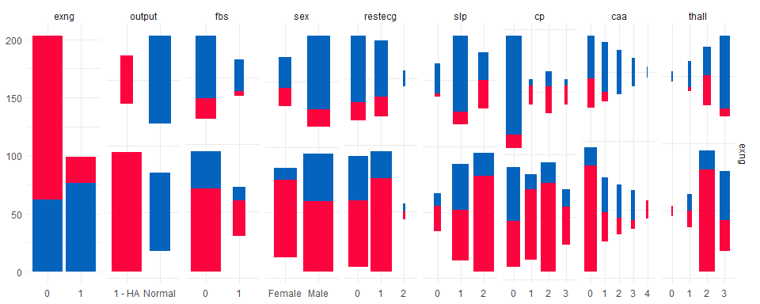

```r
new_frame <- frame %>%
              select(exng, output, fbs, sex, restecg, slp, cp, caa, thall)

y_axis = c('exng')

DrawPairs(new_frame, y_axis, type='cat')
```

- People with absence of **exng (Exercise Induced Angina)** are more likely to have **heart problem**

### restecg

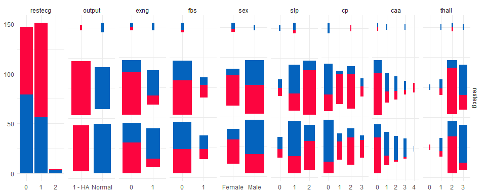

```r
new_frame <- frame %>%
              select(restecg, output, exng, fbs, sex, slp, cp, caa, thall)

y_axis = c('restecg')

DrawPairs(new_frame, y_axis, type='cat')
```

- **restecg (Resting Electrocardiographic Results)** has **poor** relation with **heart attack**

### Slope

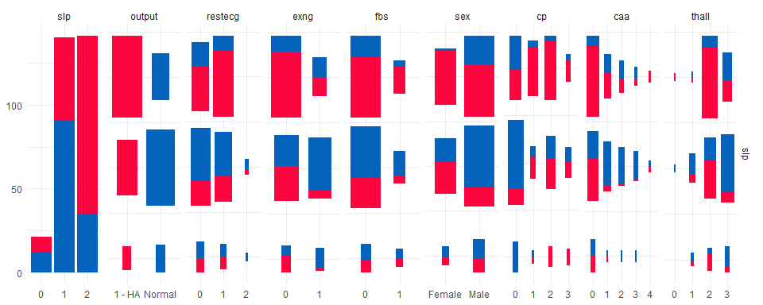

```r
new_frame <- frame %>%
              select(slp, output, restecg, exng, fbs, sex, cp, caa, thall)

y_axis = c('slp')

DrawPairs(new_frame, y_axis, type='cat')
```

- **Slope** has positive relation with **Heart Attack**
- People with **Slope == 2** have much higher chance of **heart attack**

### Chest Pain

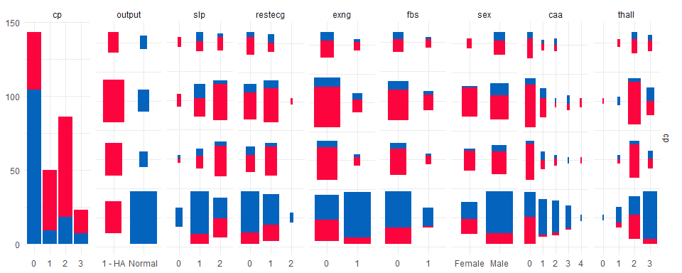

```r
new_frame <- frame %>%
              select(cp, output, slp, restecg, exng, fbs, sex, caa, thall)

y_axis = c('cp')

DrawPairs(new_frame, y_axis, type='cat')
```

- **typical angina** has lower chance of **heart attack** than **other chest pains**
- **Chest Pains** has higher chance of **heart attack**

### N of major vessels

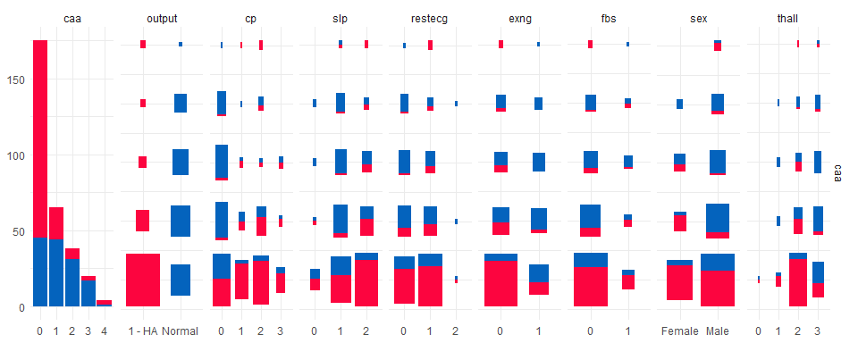

```r
new_frame <- frame %>%
              select(caa, output, cp, slp, restecg, exng, fbs, sex, thall)

y_axis = c('caa')

DrawPairs(new_frame, y_axis, type='cat')
```

- **Caa (n of major vessels)** has **negative** relation with **heart attack**
- People with **0 major vessels** have much higher chance of **heart attack**

### Thall

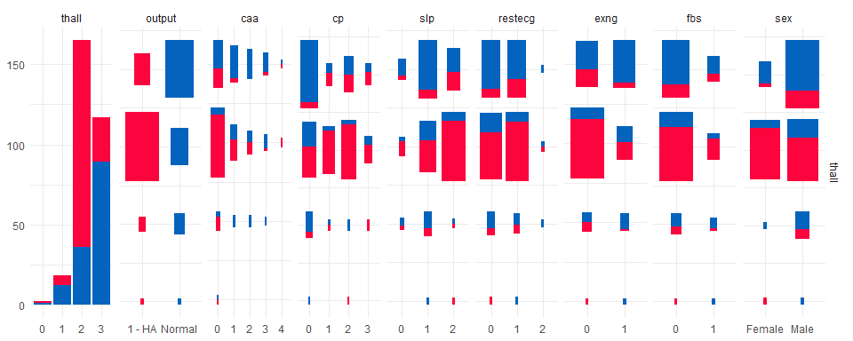

```r
new_frame <- frame %>%
              select(thall, output, caa, cp, slp, restecg, exng, fbs, sex)

y_axis = c('thall')

DrawPairs(new_frame, y_axis, type='cat')
```

- People with **Thall == 2** have much higher chance of **heart attack**

### Heart Attack

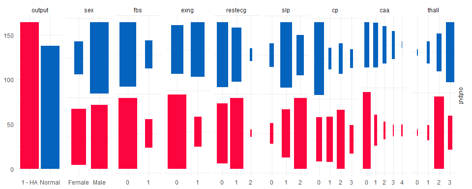

```r
new_frame <- frame %>%
              select(output, sex, fbs, exng, restecg, slp, cp, caa, thall)

y_axis = c('output')

DrawPairs(new_frame, y_axis, type='cat')
```

## Age effect on other Attributes

> Categorical data

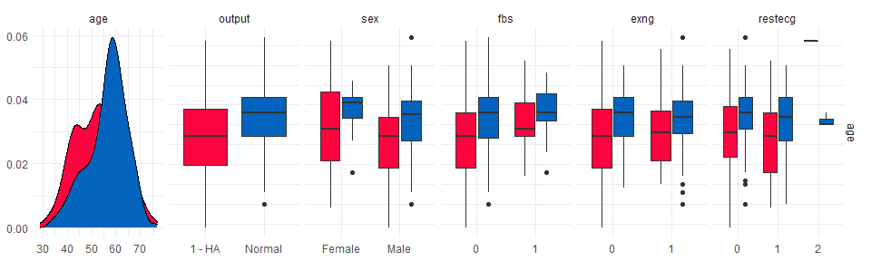

```r
new_frame <- frame %>%
              select(age, output, sex, fbs, exng, restecg)

y_axis = c('age')

DrawPairs(new_frame, y_axis, type='cat')
```

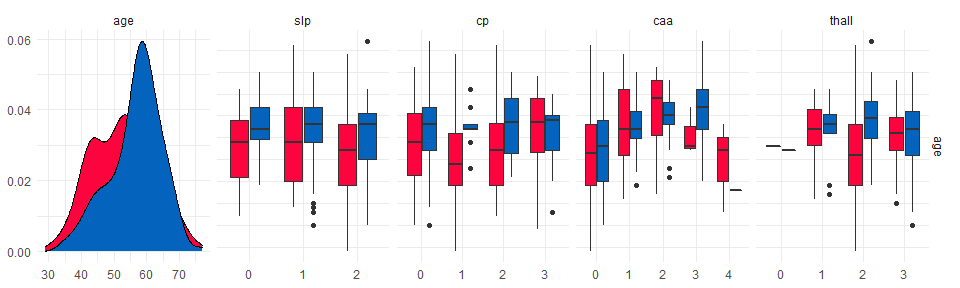

```r
new_frame <- frame %>%
              select(age, slp, cp, caa, thall, output)

y_axis = c('age')
DrawPairs(new_frame, y_axis, type='cat2')
```

> Quantitative data

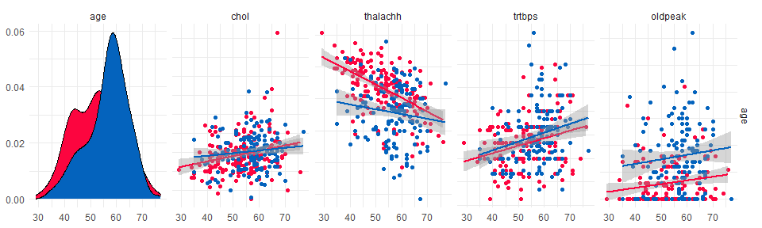

```r
new_frame <- frame %>%
              select(age, chol, thalachh, trtbps, oldpeak, output)

y_axis = c('age')
DrawPairs(new_frame, y_axis, type='int')
```

## Cholestoral effect effect on other Attributes

> Categorical data

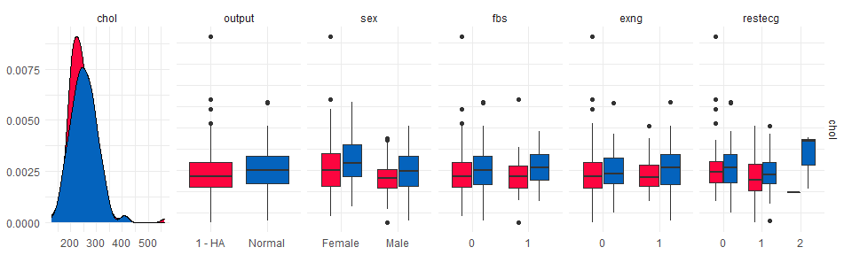

```r
new_frame <- frame %>%
              select(chol, output, sex, fbs, exng, restecg)

y_axis = c('chol')
DrawPairs(new_frame, y_axis, type='cat')
```

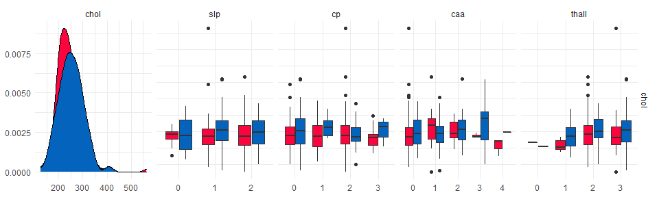

```r
new_frame <- frame %>%
              select(chol, slp, cp, caa, thall, output)

y_axis = c('chol')
DrawPairs(new_frame, y_axis, type='cat2')
```

> Quantitative data

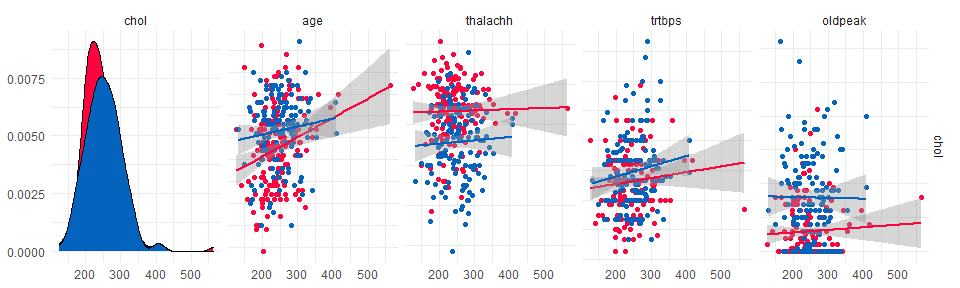

```r
new_frame <- frame %>%
              select(chol, age, thalachh, trtbps, oldpeak, output)

y_axis = c('chol')
DrawPairs(new_frame, y_axis, type='int')
```

## thalachh (Maximum Heart Rate Achieved) effect on other Attributes

> Categorical data

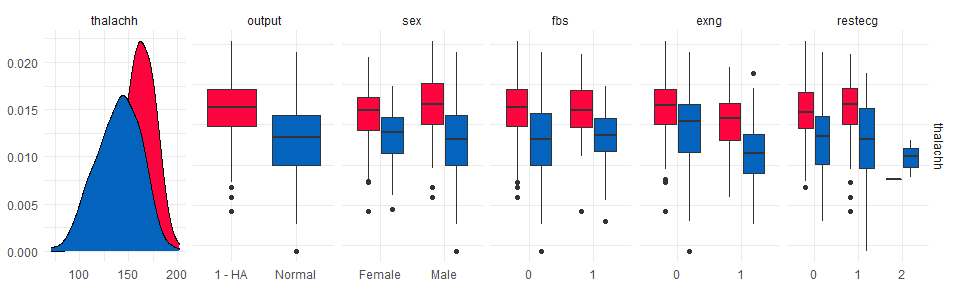

```r
new_frame <- frame %>%
              select(thalachh, output, sex, fbs, exng, restecg)

y_axis = c('thalachh')
DrawPairs(new_frame, y_axis, type='cat')
```

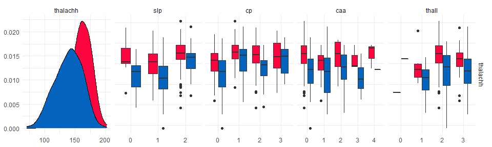

```r
new_frame <- frame %>%
              select(thalachh, slp, cp, caa, thall, output)

y_axis = c('thalachh')
DrawPairs(new_frame, y_axis, type='cat2')
```

> Quantitative data

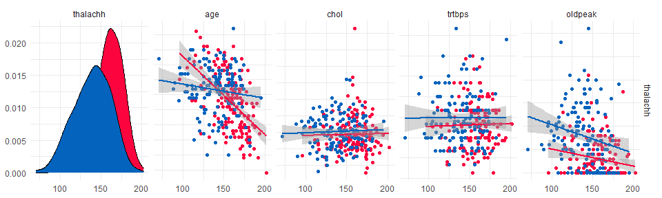

```r
new_frame <- frame %>%
              select(thalachh, age, chol, trtbps, oldpeak, output)

y_axis = c('thalachh')
DrawPairs(new_frame, y_axis, type='int')
```

## trtbps (Resting Blood Pressure) effect on other Attributes

> Categorical data

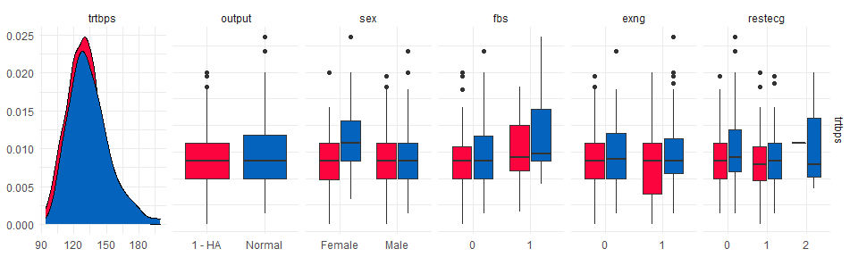

```r
new_frame <- frame %>%
              select(trtbps, output, sex, fbs, exng, restecg)

y_axis = c('trtbps')
DrawPairs(new_frame, y_axis, type='cat')
```

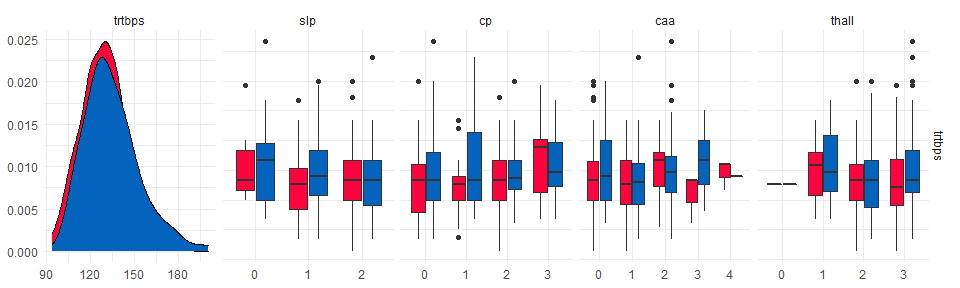

```r
new_frame <- frame %>%
              select(trtbps, slp, cp, caa, thall, output)

y_axis = c('trtbps')
DrawPairs(new_frame, y_axis, type='cat2')
```

> Quantitative data

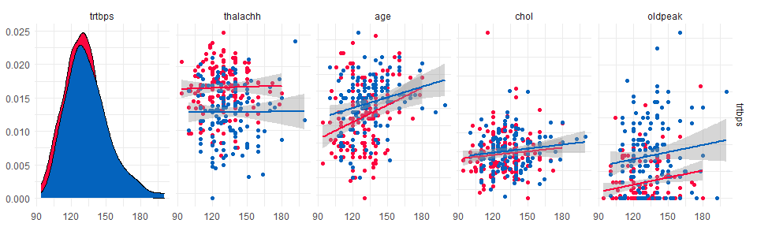

```r
new_frame <- frame %>%
              select(trtbps, thalachh, age, chol, oldpeak, output)

y_axis = c('trtbps')
DrawPairs(new_frame, y_axis, type='int')
```

## Oldpeak (ST depression induced by exercise relative to rest) effect on other Attributes

> Categorical data

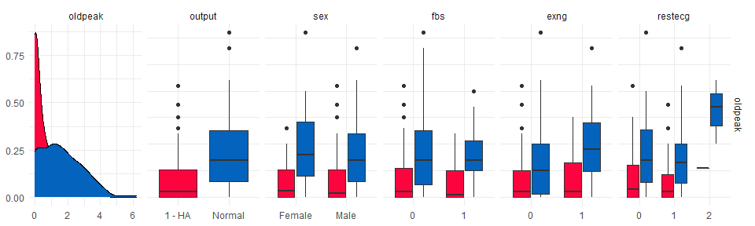

```r
new_frame <- frame %>%
              select(oldpeak, output, sex, fbs, exng, restecg)

y_axis = c('oldpeak')
DrawPairs(new_frame, y_axis, type='cat')
```

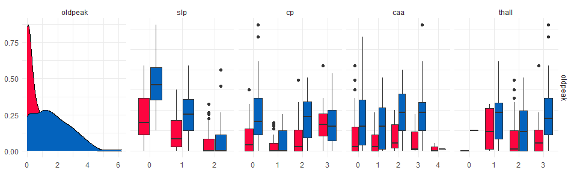

```r
new_frame <- frame %>%
              select(oldpeak, slp, cp, caa, thall, output)

DrawPairs(new_frame, y_axis, type='cat2')
```

> Quantitative data

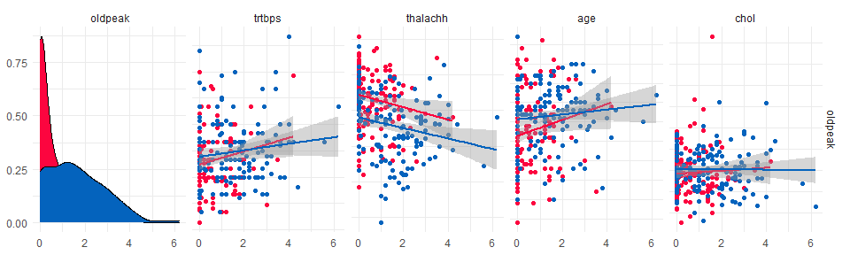

```r
new_frame <- frame %>%
              select(oldpeak, trtbps, thalachh, age, chol, output)

y_axis = c('oldpeak')
DrawPairs(new_frame, y_axis, type='int')
```

## Quantitative correlation

```r
library(corrplot)

coor_frame = df %>%
              select(age, chol, thalachh, trtbps, oldpeak)

corr0 <- cor( method = "pearson", coor_frame[sapply(coor_frame, function(x) !is.factor(x))])

hchart(corr0, type = "heatmap") %>%
    hc_plotOptions(
           series = list(
             boderWidth = 0,
             dataLabels = list(enabled = FALSE)
    ))
```

[interactive chart not shown]